# The Apple Vision Pro’s Stock Market Impact

## My Dataset

I found this “Apple Stock Data and Key Affiliated Companies” (specifically “AAPL_daily_data”) dataset after searching through Kaggle.

I will be modelling the changes in daily stock closing prices for Apple. I am specifically interested in the data spanning a few months around June 5th, 2023, the day the Apple vision Pro was announced.

In 2023, Apple announced a innovative piece of recreational technology. The goal of this study is to determine whether the promise of innovation alone can positively influence shareholder decisions.

## Presenting the Data

```r
library(itsmr)
library(knitr)
library(dplyr)
```

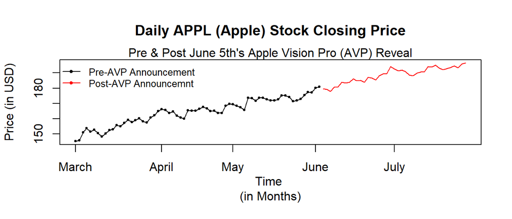

```r
apple_data <- read.csv("AAPL_daily_data.csv", header = TRUE)
split_dates <- strsplit(as.character(apple_data$Date), "-")
apple_data$Month <- sapply(split_dates, function(x) as.numeric(x[2]))
clean_apple_base <- apple_data[,c("Date", "Month", "Close")]

start_date <- as.Date("2023-03-01")
end_date <- as.Date("2023-07-31")

final_apple_stock<- clean_apple_base[clean_apple_base$Date >= start_date
                          & clean_apple_base$Date <= end_date, ]
ticks <- c(min(final_apple_stock$Date[final_apple_stock$Month == 3]),
           min(final_apple_stock$Date[final_apple_stock$Month == 4]),
                 min(final_apple_stock$Date[final_apple_stock$Month == 5]),
                 min(final_apple_stock$Date[final_apple_stock$Month == 6]),
                 min(final_apple_stock$Date[final_apple_stock$Month == 7]))

month_labels <- c("March","April", "May", "June", "July")
vision_pro_release <- as.Date("2023-06-05")

pre_june_5 <- final_apple_stock[final_apple_stock$Date < vision_pro_release, ]
post_june_5 <- final_apple_stock[final_apple_stock$Date >=vision_pro_release, ]

axis.apple <- function(){tick_indices <- match(ticks, final_apple_stock$Date)
  axis(side = 1, at = tick_indices,labels = month_labels,las = 1) }

plot.apple <- function(x.range = c(1, 105),
                       y.range = range(final_apple_stock$Close))
  {plot.ts(pre_june_5$Close,
          main = "Daily APPL (Apple) Stock Closing Price",
          xlab = "Time
(in Months)",
ylab = "Price (in USD)",
type = "o",
xlim = x.range,
ylim = y.range,
pch = 20,
cex = 0.6,
xaxt = 'n')
  lines(x= 67:105, y = post_june_5$Close  , col = "red")
  axis.apple() }

plot.apple()
mtext("Pre & Post June 5th's Apple Vision Pro (AVP) Reveal")
legend("topleft",legend = c("Pre-AVP Announcement", "Post-AVP Announcemnt"),
col = c("black", "red"),pch = 20,lty = 1,bty = "n",cex = 0.8)
```

The data shows a global upward trend over time with a good bit of variance. The fluctuations in variance seem almost cyclical, suggesting the presence of seasonality.

We will now begin with trend estimation, comparing polynomial regression and MA smoothing methods to see which best fits our data.

## Trend Estimation

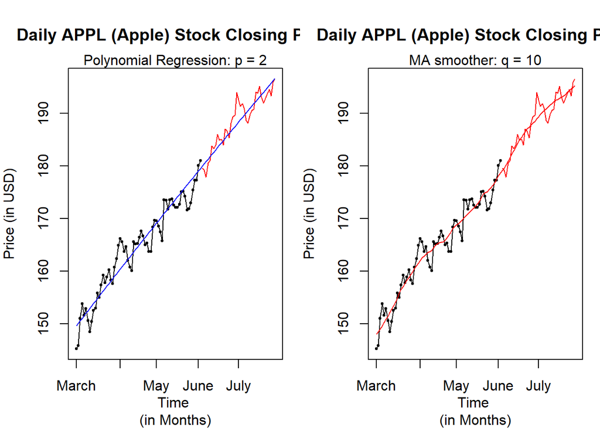

```r
m.pr <- trend(final_apple_stock$Close, p = 2)
m.ma <- smooth.ma(final_apple_stock$Close, q = 10)

par(mfrow = c(1,2), mar = c(4,4,4,1))

plot.apple();
mtext("Polynomial Regression: p = 2")
lines(m.pr, col = "blue")

plot.apple(); mtext("MA smoother: q = 10")
lines(m.ma, col = "red")
```

Compared to polynomial regression, MA smoothing seems to better capture the fluctuations in the data’s trend over time.

Moving forward, we’ll compare the data residuals for both methods.

## Trend Estimation - Residuals

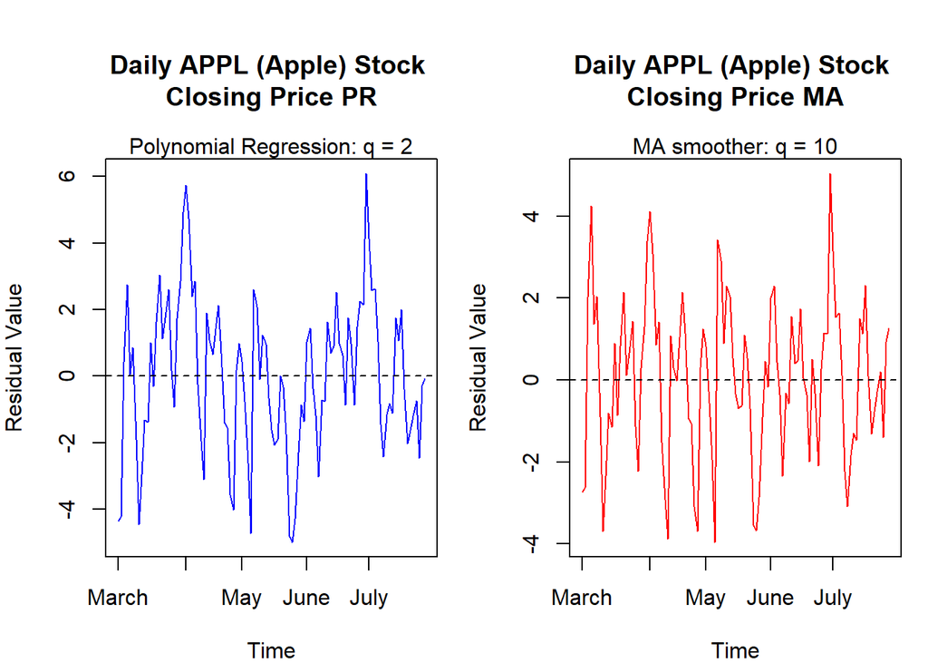

```r
par(mfrow = c(1,2), mar = c(4,4,6,1))

rm.pr <- final_apple_stock$Close - m.pr
plot.ts(rm.pr,
main = "Daily APPL (Apple) Stock
Closing Price PR",
ylab = "Residual Value",
xaxt = "n",
col = "blue")
axis.apple(); mtext("Polynomial Regression: q = 2")
abline(h = 0, lty = 2)

rm.ma <- final_apple_stock$Close - m.ma
plot.ts(rm.ma,
main = "Daily APPL (Apple) Stock
Closing Price MA",
ylab = "Residual Value",
xaxt = "n",
col = "red")
axis.apple(); mtext("MA smoother: q = 10")
abline(h = 0, lty = 2)
```

Looking at trend residual amplitudes, MA smoothing does a much better job smoothing out the data.

We will henceforth proceed with MA smoothing for our modelling.

Let’s now take a look at seasonality within the data, this time comparing Harmonic Regression with the S1 Method

## Seasonality Estimation - Harmonic Regression Vs. S1 Method

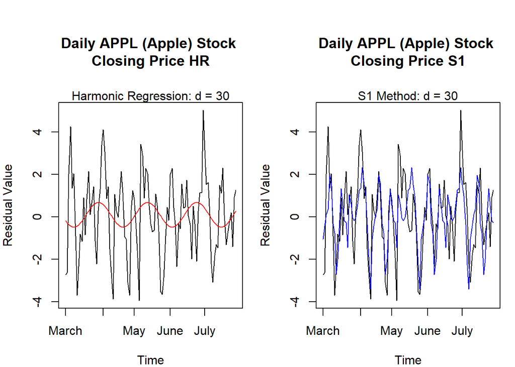

```r
s.hr <- hr(rm.ma, d = 30)
s.s1 <- season(rm.ma, d = 30)

par(mfrow = c(1,2), mar = c(4,4,7,1))
plot.ts(rm.ma,
main = "Daily APPL (Apple) Stock
Closing Price HR",
xaxt = "n",
ylab = "Residual Value")
axis.apple(); mtext("Harmonic Regression: d = 30")
lines(s.hr, col = "red")

plot.ts(rm.ma,
main = "Daily APPL (Apple) Stock
Closing Price S1",
xaxt = "n",
ylab = "Residual Value")
axis.apple(); mtext("S1 Method: d = 30")
lines(s.s1, col = "blue")
```

This being said, we can now look at ACF residuals for the S1 method, as well as the deseasonalized data.

## Sample ACF - S1 Method

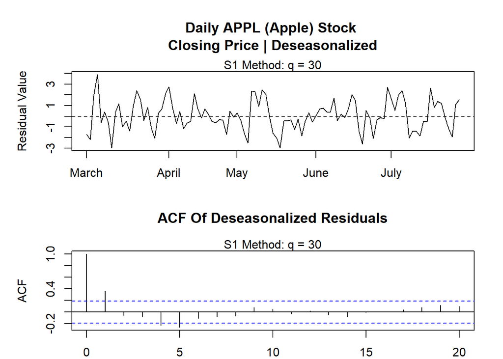

```r
par(mfrow = c(2,1), mar = c(2,5,5,2))
y.s1 <- rm.ma - s.s1
plot.ts(y.s1,
main = "Daily APPL (Apple) Stock
Closing Price | Deseasonalized",
xaxt = "n",
ylab = "Residual Value")
axis.apple(); mtext("S1 Method: q = 30"); abline(h = 0, lty = 2)

acf(y.s1,
main = "ACF Of Deseasonalized Residuals",
xlab = "Lag")
mtext("S1 Method: q = 30")
```

Removing the seasonality from the data shows that there is a subtle amount of motif repetition in the data. This would suggest that the data does have a seasonal structure, if only minimal.

We can now move on to determining the ideal parameters for an ARMA process.

## Modelling the data

```r
#no success with hr keep getting upward lines
#had to include march data to set seasonality to 30
#

M.0 <- c("trend" , 1, "season", 30)
M.1 <- c("log" , "diff", 30)

R.0 <- Resid(pre_june_5$Close, M = M.0)
R.1 <- Resid(pre_june_5$Close, M = M.1)


A.0 <- arma(x = R.0, p = 0, q = 0)
A.1 <- arma(x = R.1, p = 0, q = 0)


fc.0 <- forecast(pre_june_5$Close, M = M.0, a = A.0, h = 39, opt = 0)
fc.1 <- forecast(pre_june_5$Close, M = M.1, a = A.1, h = 39, opt = 0)


plot.forecast <- function(fc){ # input prediction
  points(x = 67:105,
         y = fc$pred,
         col = "blue", type = "o", pch = 20)

lines(67:105, fc$l, col = "red", lty = 3)
lines(67:105, fc$u, col = "red", lty = 3)
}
```

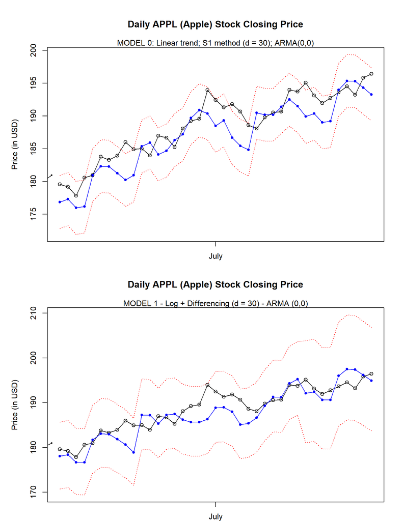

```r
par(mfrow = c(2,1), mar = c(2,5,5,2))

#leaves model 5 times
plot.apple(x.range = c(67,105),
           y.range = range(post_june_5$Close, fc.0$l, fc.0$u))
mtext("MODEL 0: Linear trend; S1 method (d = 30); ARMA(0,0)")
points(x = 67:105, y = post_june_5$Close, type = "o")
plot.forecast(fc.0)


# --- Model 1 - leaves model  0 times
plot.apple(x.range = c(67,105),
           y.range = range(post_june_5$Close,fc.1$l,fc.1$u))
mtext("MODEL 1 - Log + Differencing (d = 30) - ARMA (0,0)")

points(x = 67:105, y = post_june_5$Close, type = "o")
plot.forecast(fc.1)
```

From here we will use AIC diagnostics to determine each models ideal ARMA parameters and decide which model fits our data best.

## AIC Diagnostics

```r
aic.0 <- aic.1 <- matrix(data = 0, nrow = 6, ncol = 6)


for (p in 0:5) for (q in 0:5) {

  R0.fit <- arima(R.0, order = c(p,0,q))
  R1.fit <- arima(R.1, order = c(p,0,q),
                  optim.control = list(maxit = 1000))


  aic.0[p+1,q+1] <- R0.fit$aic
  aic.1[p+1,q+1] <- R1.fit$aic
}
rownames(aic.0) <- rownames(aic.1) <- paste("p =",0:5)
colnames(aic.0) <- colnames(aic.1) <- paste("q =",0:5)


kable(x = aic.0, caption = "AIC for ARMA(p,q) models; Classical Model 0")
```

AIC for ARMA(p,q) models; Classical Model 0

|  | q = 0 | q = 1 | q = 2 | q = 3 | q = 4 | q = 5 |
| --- | --- | --- | --- | --- | --- | --- |
| p = 0 | 286.8550 | 266.4188 | 266.2094 | 267.4025 | 267.5996 | 264.1259 |
| p = 1 | 264.7204 | 265.5030 | 267.3086 | 269.0388 | 271.0491 | 266.0790 |
| p = 2 | 265.8262 | 267.3251 | 269.2929 | 266.6895 | 266.2413 | 267.8681 |
| p = 3 | 267.5503 | 269.2414 | 266.9127 | 267.2065 | 266.5881 | 269.5981 |
| p = 4 | 268.7997 | 270.7022 | 266.0238 | 270.3619 | 271.0770 | 270.2670 |
| p = 5 | 270.1515 | 269.8395 | 267.9994 | 269.1956 | 270.8271 | 270.0260 |

```r
kable(x = aic.1, caption = "AIC for ARMA(p,q) models; Classical Model 3")
```

AIC for ARMA(p,q) models; Classical Model 3

|  | q = 0 | q = 1 | q = 2 | q = 3 | q = 4 | q = 5 |
| --- | --- | --- | --- | --- | --- | --- |
| p = 0 | -170.6687 | -185.0930 | -186.8603 | -185.8302 | -187.8516 | -187.0254 |
| p = 1 | -190.5062 | -188.7552 | -187.2519 | -185.5740 | -183.7027 | -186.1895 |
| p = 2 | -188.6800 | -186.9258 | -185.5827 | -183.2806 | -186.1895 | -184.7573 |
| p = 3 | -187.0221 | -185.1306 | -188.5860 | -185.2393 | -184.2404 | -187.6335 |
| p = 4 | -185.1658 | -183.2139 | -188.2738 | -185.1587 | -183.9249 | -185.6335 |
| p = 5 | -183.7792 | -181.6787 | -183.6489 | -185.6684 | -187.9122 | -179.9127 |

```r
print(paste("Index of Smallest AIC (Model 0):", which.min(aic.0)))
```

```
## [1] "Index of Smallest AIC (Model 0): 31"
```

```r
print(paste("Index of Smallest AIC (Model 1):", which.min(aic.1)))
```

```
## [1] "Index of Smallest AIC (Model 1): 2"
```

```r
fit.past.0.aic  <- arima(R.0, order = c(1,0,1))

display <- cbind(fit.past.0.aic$coef,
                 sqrt(diag(fit.past.0.aic$var.coef)))

kable(display,
      col.names = c("Estimated Coefficient", "Standard Error"),
      caption = "Model 0 - ARMA cofficients (from AIC selection)")
```

Model 0 - ARMA cofficients (from AIC selection)

|  | Estimated Coefficient | Standard Error |
| --- | --- | --- |
| ar1 | 0.3911750 | 0.2281635 |
| ma1 | 0.2818430 | 0.2344537 |
| intercept | -0.0397419 | 0.4347788 |

| Model | p | q | AIC | Noise variance $\sigma^2$ |
| --- | --- | --- | --- | --- |
| 0 | 0 | 5 | 264.1259 | 2.23 |
| 1 | 1 | 0 | -190.5062 | 0.0001766 |

The table above summarizes the results from our AIC diagnostics. From here we can compare both models using the suggested parameters.

```r
A.0.2 <- arma(x = R.0, p = 0, q = 5)
A.1.2 <- arma(x = R.1, p = 1, q = 0)


fc.0.2 <- forecast(pre_june_5$Close, M = M.0, a = A.0.2, h = 39, opt = 0)
fc.1.2 <- forecast(pre_june_5$Close, M = M.1, a = A.1.2, h = 39, opt = 0)
```

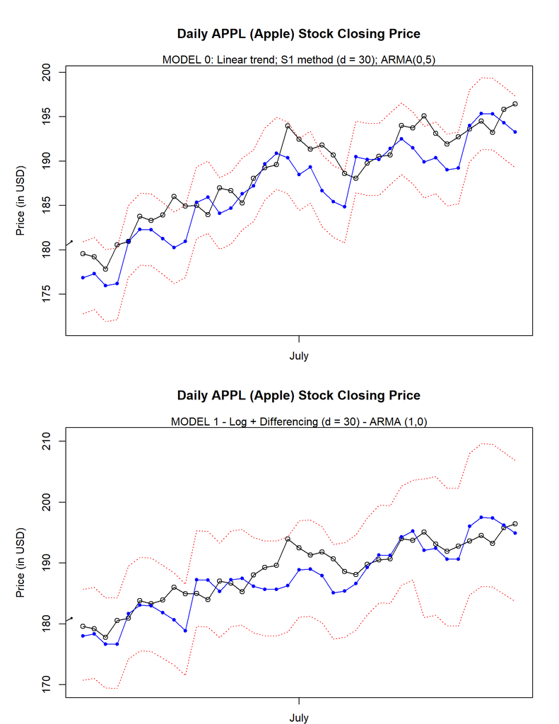

```r
par(mfrow = c(2,1), mar = c(2,5,5,2))


plot.apple(x.range = c(67,105),
           y.range = range(post_june_5$Close, fc.0.2$l, fc.0.2$u))
mtext("MODEL 0: Linear trend; S1 method (d = 30); ARMA(0,5)")
points(x = 67:105, y = post_june_5$Close, type = "o")
plot.forecast(fc.0)


plot.apple(x.range = c(67,105),
           y.range = range(post_june_5$Close,fc.1.2$l,fc.1.2$u))
mtext("MODEL 1 - Log + Differencing (d = 30) - ARMA (1,0)")

points(x = 67:105, y = post_june_5$Close, type = "o")
plot.forecast(fc.1)
```

Model 1 utilizes a log and differencing. Once again through manipulating the plot, we found that the predicted data (blue) does not exit our confidence interval.

Despite this, we can see that Model 0 better constrains and captures the shape of the data. For this reason, Model 0 is preferred.

We will can now proceed with a residual analysis for Model 0.

## Comparing Model 0 Residuals - ARMA (0,0) Vs. ARMA (0,5)

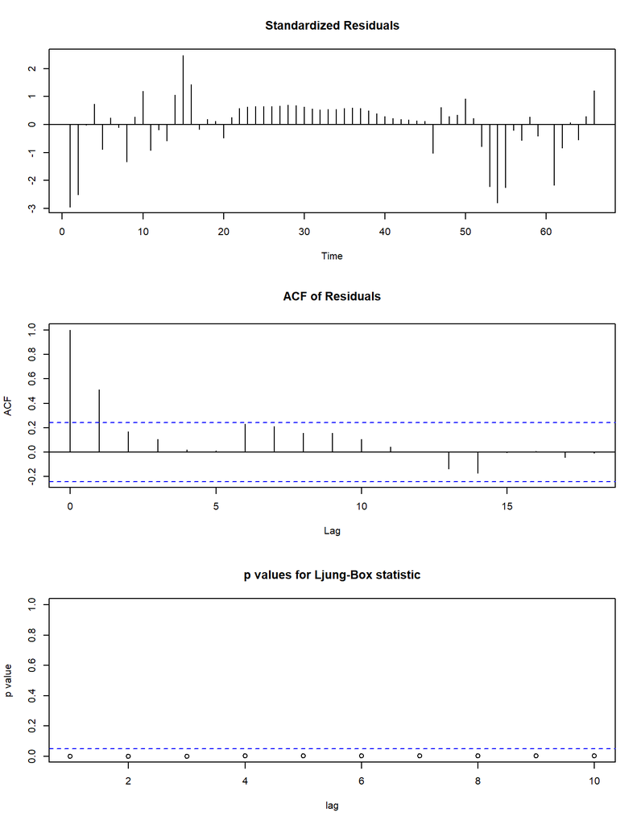

```r
tsdiag(arima(R.0, order = c(0,0,0)))
```

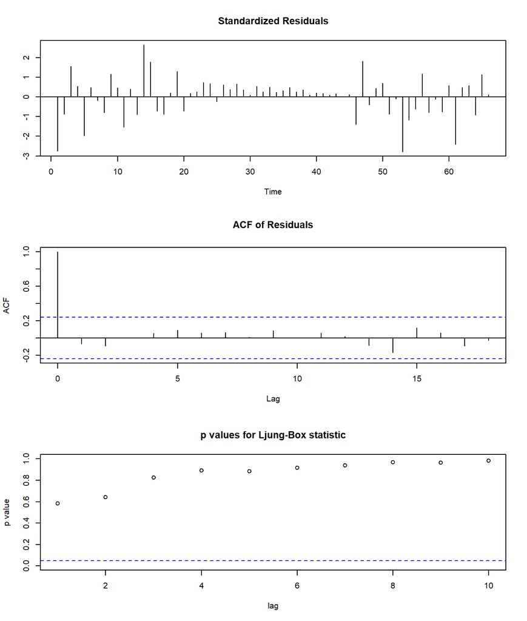

```r
tsdiag(arima(R.0, order = c(0,0,5)))
```

Looking at both ARMA(0,0) and ARMA (0,5) process residuals, we can see that our new ARMA(0,5) process better randomizes the data. There a no major trends or cycles present.

## Summarizing our Model (Final Formula)

[output not shown]

## Conclusion

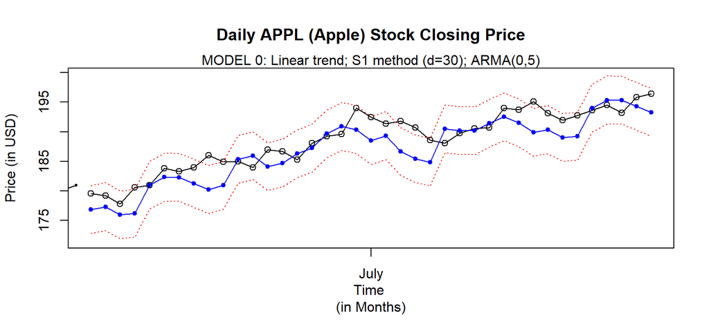

```r
plot.apple(x.range = c(67,105),
           y.range = range(post_june_5$Close, fc.0.2$l, fc.0.2$u))
mtext("MODEL 0: Linear trend; S1 method (d=30); ARMA(0,5)")
points(x = 67:105, y = post_june_5$Close, type = "o")
plot.forecast(fc.0)
```

Our final seems to mostly capture our data’s behavior.

In regard to our hypothesis, our model suggests unexpected upward trends in over time, in regard to the real data. This real data seems to somewhat be mostly above our predicted data. This would add some weight to our initial theory that the Apple Vision Pro’s announcement stimulated Apple shareholders to further invest in the company’s stock. It also suggests that the rise of Apple’s stock was projected to rise to the real data’s levels, albeit without notable price hikes showcased in the 30 days following the Vision Pro’s reveal.

Some issues in our interpretation lie in the many exogenous factors that affect a companies stock price, such as the companies performance, public perception, and private dealings to name a few.